# Parameter Setting by Optimization

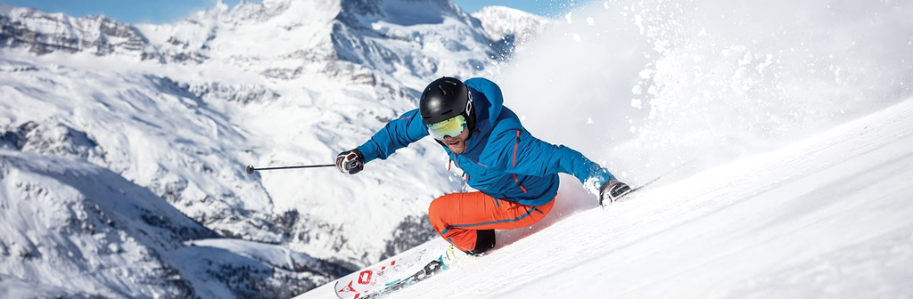

== document setup ==

## Synopsis

Some model construction methods rely on having an appropriate optimization method to set parameters to satisfy a criterion for best fit.

Here are some optimization methods ...

- Batch Gradient Descent
- Iterative Gradient Descent
- Stochastic Gradient Descent
- Newton's 2nd Order
- other optimization methods

**Terms**

- Model parameters
- Optimization

## Exposition

### Set Parameters | Cost Function: Sum of Squared Errors

#### Data

Consider this dataset.

**data**

| x1 | outcome |
| --- | --- |
| 1.0 | 1.0 |
| 2.0 | 0.5 |
| 3.0 | 3.0 |
| 4.0 | 3.0 |
| 6.0 | 4.0 |
| 6.5 | 5.5 |
| 7.0 | 7.0 |
| 9.0 | 6.0 |

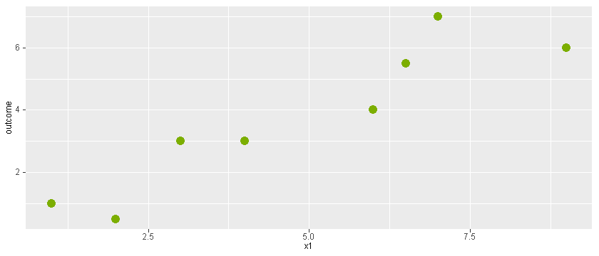

#### Model

Form of model: $$ \hat{y} = mx$$

Criterion for best fit (cost function): $$ minimize \sum_{i=1}^N (y_i - \hat{y}_i)^2 = minimize \sum_{i=1}^N (y_i - mx_i)^2 $$

Criterion change rate (derivative of cost function): $$ slope = -2 \sum_{i=1}^N (y_i - \hat{y}_i)x_i = -2 \sum_{i=1}^N (y_i - mx_i)x_i $$

| model | cost | cost_slope |
| --- | --- | --- |
| function defined | function defined | function defined |

#### Iterate

**Initialize**

| R | m.start |
| --- | --- |
| 0.001 | -0.5 |

**Iteration 0**

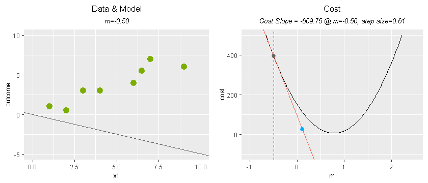

**Iteration 1**

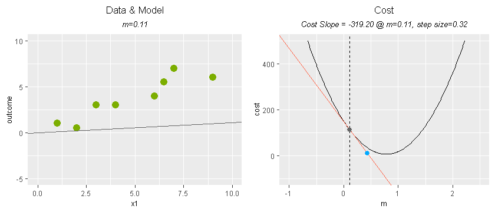

**Iteration 2**

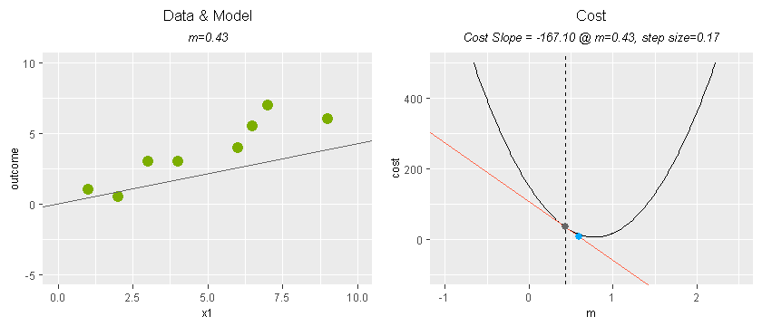

**Iteration 20**

Batch gradient descent converges to optimal solution at m = 0.78.

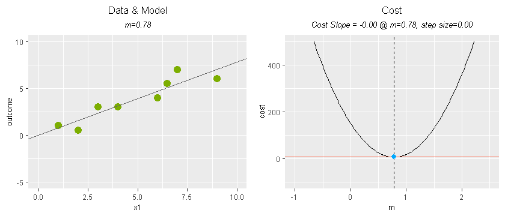

### Set Parameters | Cost Function: Sum of Squared Errors, Non-Convex

#### Data

Consider this dataset.

**data**

| x1 | outcome |
| --- | --- |
| -5.0 | 1 |
| -3.0 | 1 |
| -2.0 | 1 |
| 1.0 | 1 |
| 2.0 | 0 |
| 3.0 | 1 |
| 3.5 | 0 |
| 4.0 | 0 |
| 6.0 | 0 |
| 6.5 | 0 |
| 9.0 | 0 |

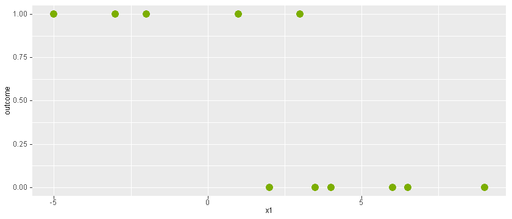

#### Model

Form of model: $$ \hat{y} = \frac{1}{1 + e^{-bx}} $$

Criterion for best fit (cost function): $$ minimize \sum_{i=1}^N (y_i - \hat{y}_i)^2 = minimize \sum_{i=1}^N \big(y_i - \frac{1}{1 + e^{-bx}}\big)^2 $$

Criterion change rate (derivative of cost function): $$ estimated ... $$

| model | cost | cost_slope |
| --- | --- | --- |
| function defined | function defined | function defined |

#### Iterate

**Initialize**

| R | b.start |
| --- | --- |
| 2 | -2 |

**Iteration 0**

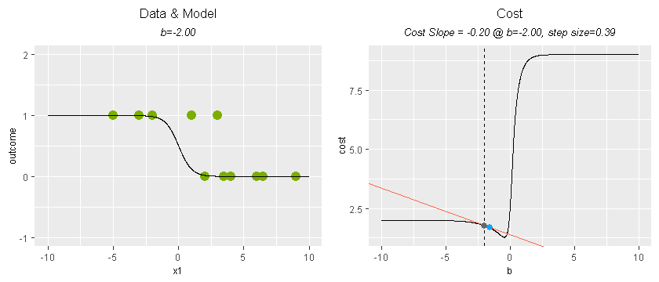

**Iteration 1**

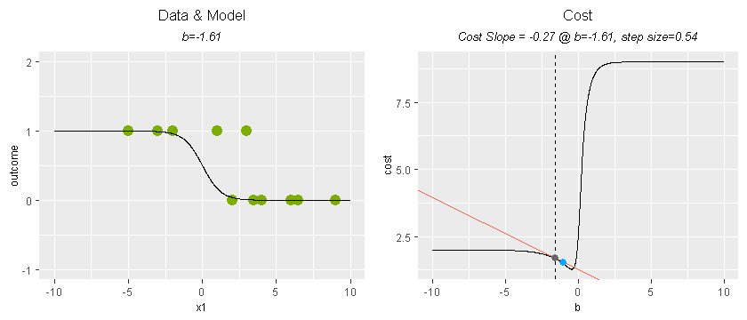

**Iteration 2**

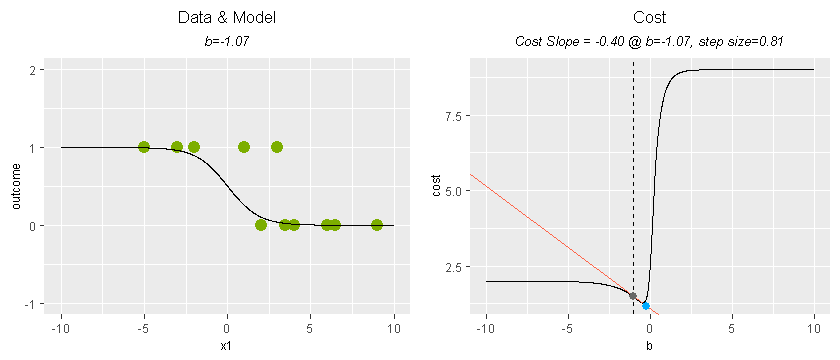

**Iteration 3**

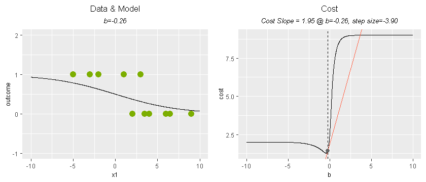

**Iteration 4**

Batch gradient descent with sum of squared errors criterion for best fit does not converge quickly (or possibly ever).

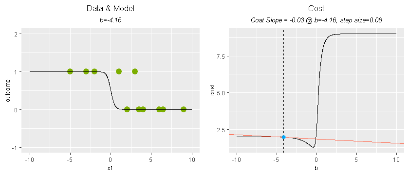

### Set Parameters | Cost Function: Special for Logistic Regression

#### Data

Consider this dataset.

**data**

| x1 | outcome |
| --- | --- |
| -5.0 | 1 |
| -3.0 | 1 |
| -2.0 | 1 |
| 1.0 | 1 |
| 2.0 | 0 |
| 3.0 | 1 |
| 3.5 | 0 |
| 4.0 | 0 |
| 6.0 | 0 |
| 6.5 | 0 |
| 9.0 | 0 |

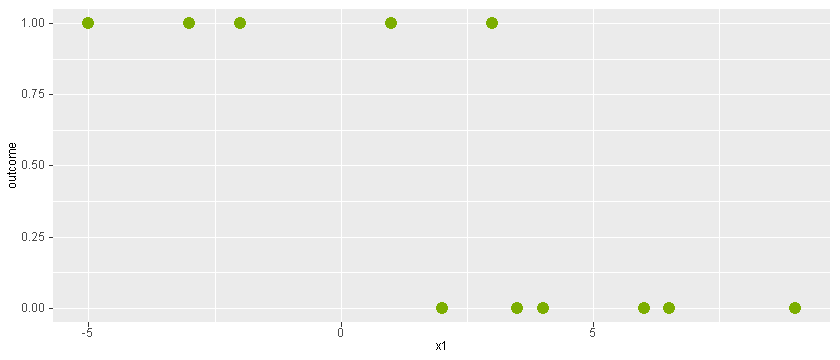

#### Model

Form of model: $$ \hat{y} = \frac{1}{1 + e^{-bx}} $$

Criterion for best fit (cost function): $$ minimize \sum_{i=1}^N -\big(y_i - log(\hat{y}_i)\big) - \big((1-y_i)log(1-\hat{y}_i)\big) =$$ $$minimize \sum_{i=1}^N -\big(y_i - log\big(\frac{1}{1 + e^{-bx_i}}\big)\big) - \big((1-y_i)log\big(1-\frac{1}{1 + e^{-bx_i}}\big)\big) $$

Criterion change rate (derivative of cost function): $$ slope = - \sum_{i=1}^N (y_i - \hat{y}_i)x_i = - \sum_{i=1}^N \big(y_i - \frac{1}{1 + e^{-bx_i}}\big)x_i $$

| model | cost | cost_slope |
| --- | --- | --- |
| function defined | function defined | function defined |

#### Iterate

**Initialize**

| R | b.start |
| --- | --- |
| 0.15 | -2 |

**Iteration 0**

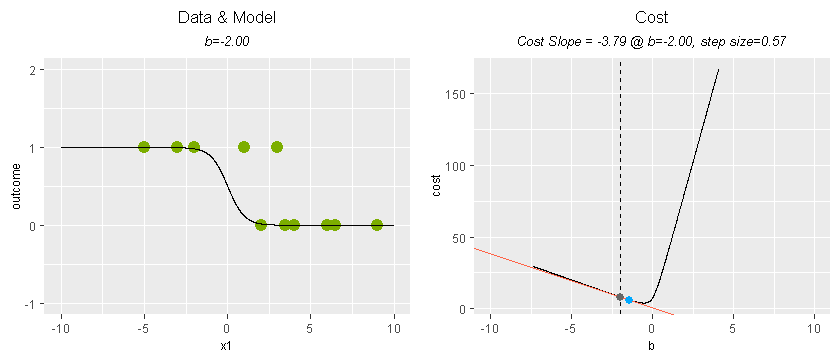

**Iteration 1**

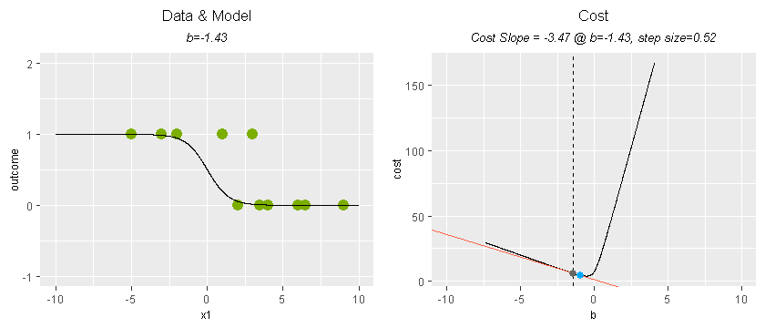

**Iteration 2**

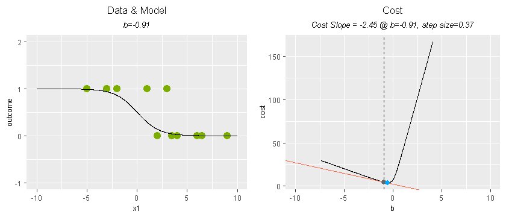

**Iteration 3**

Batch gradient descent with special criterion for best fit converges to optimal solution at b = -0.54.

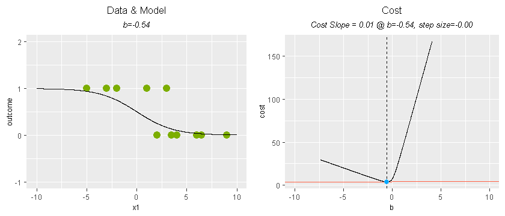

### Set Parameters | Cost Function: Sum of Squared Errors, Non-Convex, Optimal Solution

#### Data

Consider this dataset.

**data**

| x1 | outcome |
| --- | --- |
| -0.50 | -10.761793 |
| -0.40 | -13.041581 |
| -0.30 | -16.056636 |
| -0.10 | -30.771308 |
| 0.01 | 34.799199 |
| 0.05 | 53.979875 |
| 0.10 | 7.204714 |
| 0.15 | -3.183375 |
| 0.20 | -8.445647 |
| 0.30 | -14.709963 |
| 0.45 | -21.107950 |
| 0.52 | -23.739915 |
| 0.60 | -26.674947 |
| 0.70 | -30.341891 |

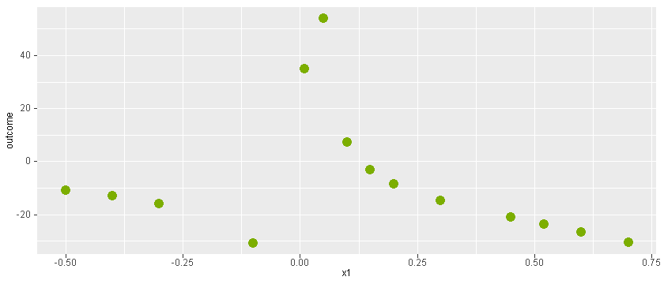

#### Model

Form of model: $$ \hat{y} = (x+b) + \frac{1}{x} + \frac{1}{x-0.01b} + (x+b)^2 - (x+b)^3 $$

Criterion for best fit (cost function): $$ minimize \sum_{i=1}^N (y_i - \hat{y}_i)^2 = minimize \sum_{i=1}^N \big(y_i - \big((x+b) + \frac{1}{x} + \frac{1}{x-0.01b} + (x+b)^2 - (x+b)^3\big) \big)^2 $$

Criterion change rate (derivative of cost function): $$ estimated ... $$

| model | cost | cost_slope |
| --- | --- | --- |
| function defined | function defined | function defined |

**Initialization**

| R | b.start |
| --- | --- |
| 0.00001 | 4 |

#### Iterate

**Iteration 0**

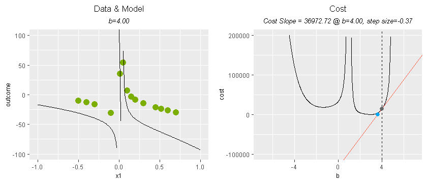

**Iteration 1**

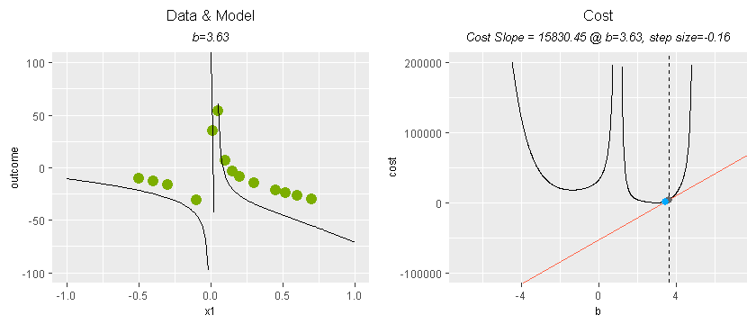

**Iteration 2**

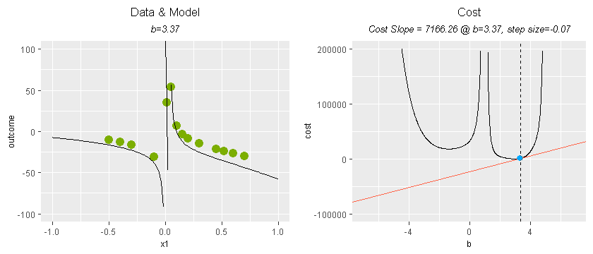

**Iteration 100**

Batch gradient descent starting at b = 4 converges to optimal solution at b = 3.

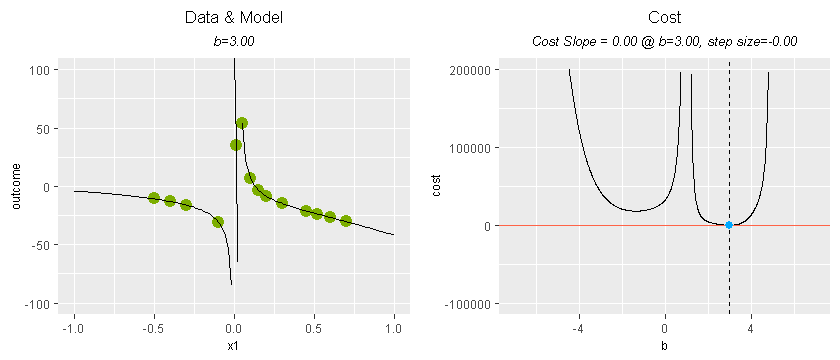

### Set Parameters | Cost: Sum of Squared Errors, Non-Convex, Non-Optimal Solution

**Initiatialization**

| R | b.start |
| --- | --- |
| 0.00001 | -4 |

**Iteration 0**

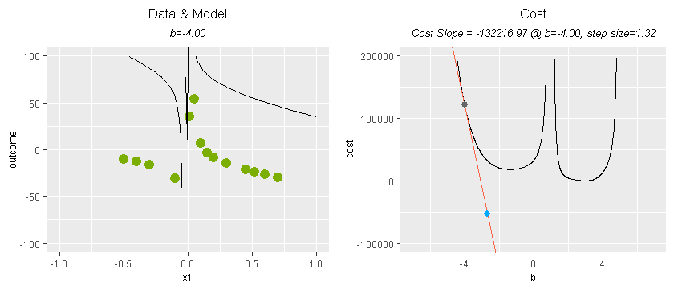

**Iteration 1**

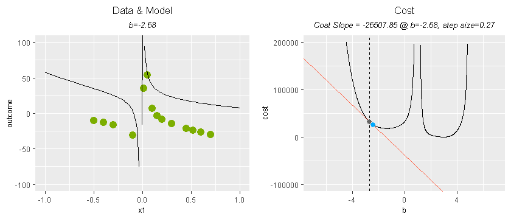

**Iteration 2**

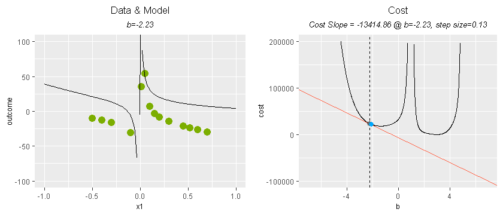

**Iteration 100**

Batch gradient descent starting from b = -4 converges to a non-optimal solution at b = -1.36.

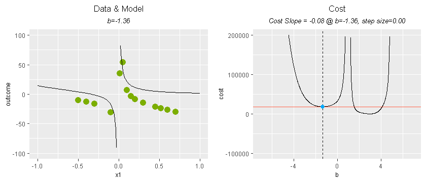

Copyright (c) Berkeley Data Analytics Group, LLC Document revised October 4, 2019